# White Wine EDA

SUDHANSHU MISHRA

Machine Learning with Python (SUM18 ML ON1)

ASSIGNMENT_7

```python
from IPython.display import HTML

HTML('''<script>
code_show=true;
function code_toggle() {
 if (code_show){
 $('div.input').hide();
 } else {
 $('div.input').show();
 }
 code_show = !code_show
}
$( document ).ready(code_toggle);
</script>
<form action="javascript:code_toggle()"><input type="submit" value="Click here to toggle on/off the raw code."></form>''')
```

# Exploratory Data Analysis on White Wine Dataset by Sudhanshu Mishra

This dataset analysis is aimed at getting a deeper insight into the data set and distribution of different factors that decide the quality of wine being produced.

## Dataset Description

The dataset is in the form of CSV file format(Comma Separated Values). CSV file is stored in the formm of tables where each row represents an independent record while each column represents an attribute. Columns of same row are separated by commas.

All wines are produced in a particular area of Portugal. Data are collected on 12 different properties of the wines one of which is Quality, based on sensory data, and the rest are on chemical properties of the wines including density, acidity, alcohol content etc. All chemical properties of wines are continuous variables. Quality is an ordinal variable with possible ranking from 1 (worst) to 10 (best). Each variety of wine is tasted by three independent tasters and the final rank assigned is the median rank given by the tasters

For more information, read [Cortez et al., 2009]. The data was last modified on October 15,2009. Following are the attributes of the dataset:

1) fixed acidity  
2) volatile acidity  
3) citric acid 4) residual sugar  
5) chlorides  
6) free sulfur dioxide 7) total sulfur dioxide  
8) density 9) pH  
10) sulphates  
11) alcohol 12) quality(ranges from 0 to 10)

[figure not shown]

```python
import numpy as np
import pandas as pd
import matplotlib.pyplot as plt
%matplotlib inline
import seaborn as sns
```

Let's view the first five rows of the imported Dataset. For this we use head()

```python
df=pd.read_csv('C:\\Users\\Sudhanshu\\Downloads\\winequality-white.csv')
df.head()
```

|  | fixed acidity | volatile acidity | citric acid | residual sugar | chlorides | free sulfur dioxide | total sulfur dioxide | density | pH | sulphates | alcohol | quality |
| --- | --- | --- | --- | --- | --- | --- | --- | --- | --- | --- | --- | --- |
| 0 | 7.0 | 0.27 | 0.36 | 20.7 | 0.045 | 45.0 | 170.0 | 1.0010 | 3.00 | 0.45 | 8.8 | 6 |
| 1 | 6.3 | 0.30 | 0.34 | 1.6 | 0.049 | 14.0 | 132.0 | 0.9940 | 3.30 | 0.49 | 9.5 | 6 |
| 2 | 8.1 | 0.28 | 0.40 | 6.9 | 0.050 | 30.0 | 97.0 | 0.9951 | 3.26 | 0.44 | 10.1 | 6 |
| 3 | 7.2 | 0.23 | 0.32 | 8.5 | 0.058 | 47.0 | 186.0 | 0.9956 | 3.19 | 0.40 | 9.9 | 6 |
| 4 | 7.2 | 0.23 | 0.32 | 8.5 | 0.058 | 47.0 | 186.0 | 0.9956 | 3.19 | 0.40 | 9.9 | 6 |

Shape of the Dataset is:

```python
df.shape
```

```
(4898, 12)
```

Size of the Dataset is:

```python
df.size
```

```
58776
```

Statistical analysis of the Dataset

```python
df.describe(include='all')
```

|  | fixed acidity | volatile acidity | citric acid | residual sugar | chlorides | free sulfur dioxide | total sulfur dioxide | density | pH | sulphates | alcohol | quality |
| --- | --- | --- | --- | --- | --- | --- | --- | --- | --- | --- | --- | --- |
| count | 4898.000000 | 4898.000000 | 4898.000000 | 4898.000000 | 4898.000000 | 4898.000000 | 4898.000000 | 4898.000000 | 4898.000000 | 4898.000000 | 4898.000000 | 4898.000000 |
| mean | 6.854788 | 0.278241 | 0.334192 | 6.391415 | 0.045772 | 35.308085 | 138.360657 | 0.994027 | 3.188267 | 0.489847 | 10.514267 | 5.877909 |
| std | 0.843868 | 0.100795 | 0.121020 | 5.072058 | 0.021848 | 17.007137 | 42.498065 | 0.002991 | 0.151001 | 0.114126 | 1.230621 | 0.885639 |
| min | 3.800000 | 0.080000 | 0.000000 | 0.600000 | 0.009000 | 2.000000 | 9.000000 | 0.987110 | 2.720000 | 0.220000 | 8.000000 | 3.000000 |
| 25% | 6.300000 | 0.210000 | 0.270000 | 1.700000 | 0.036000 | 23.000000 | 108.000000 | 0.991723 | 3.090000 | 0.410000 | 9.500000 | 5.000000 |
| 50% | 6.800000 | 0.260000 | 0.320000 | 5.200000 | 0.043000 | 34.000000 | 134.000000 | 0.993740 | 3.180000 | 0.470000 | 10.400000 | 6.000000 |
| 75% | 7.300000 | 0.320000 | 0.390000 | 9.900000 | 0.050000 | 46.000000 | 167.000000 | 0.996100 | 3.280000 | 0.550000 | 11.400000 | 6.000000 |
| max | 14.200000 | 1.100000 | 1.660000 | 65.800000 | 0.346000 | 289.000000 | 440.000000 | 1.038980 | 3.820000 | 1.080000 | 14.200000 | 9.000000 |

Checking for NULL VALUES

```python
df.isnull().sum()
```

```
fixed acidity           0
volatile acidity        0
citric acid             0
residual sugar          0
chlorides               0
free sulfur dioxide     0
total sulfur dioxide    0
density                 0
pH                      0
sulphates               0
alcohol                 0
quality                 0
dtype: int64
```

## Univariate Analysis

"Uni" means one, "Variate" means variable.Thus Univariate means one variable.Hence in Univariate Analysis we focus on just one variable at a time. Univariate annalysis helps in finding out the Outliers present in the dataset.

We also tend to find the dsitribution of the data on the dataset which can further help us for the Bivaraite/Multivariate analysis.

### Quality-count plot

From the quality count plot we can say:

1. Maximum number of wines have been rated 6
2. The second hightest rating is 5.
3. Hence we may conclude that the wine tasters were not given good quality of wine to test

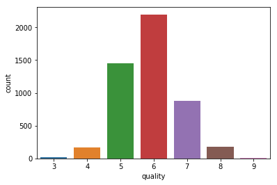

```python
sns.countplot(x = 'quality', data = df)
```

### alcohol-count plot

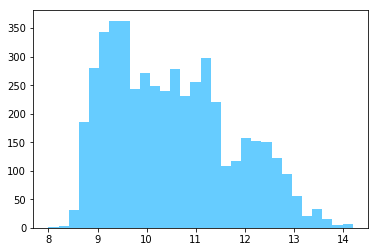

```python
plt.hist(x = 'alcohol' , data = df , bins=30,color='#66ccff')
```

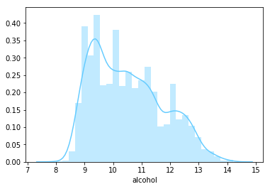

```python
sns.distplot(df['alcohol'],color='#66ccff')
```

### sulphates - Count plot

Following conclusions can be drawn from the given graphs

1. Distrbution seems to be normal
2. Most of wines have sulphate content ranging between 0.4% to 0.6% by volume
3. A lot many outliers can be seen

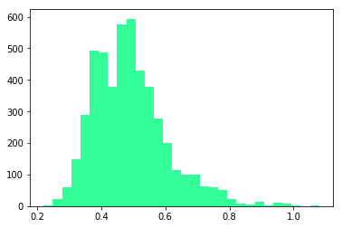

```python
plt.hist(x = 'sulphates', data = df , bins = 30,color='#33ff99')
plt.show()
```

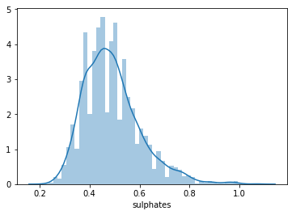

```python
sns.distplot(df['sulphates'])
```

### pH - Count plot.

The plots can help us derve the following facts:

```
1. The curve is normally distributed
2. Most of the wine have approximately 3.2 as the highest pH
```

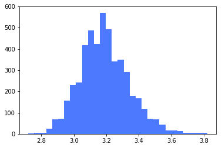

```python
plt.hist(x = 'pH' , data = df , bins =30,color='#4d79ff' )
plt.show()
```

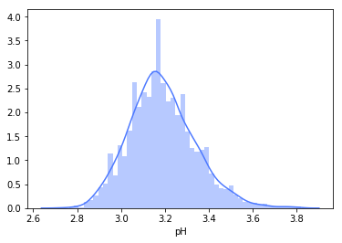

```python
sns.distplot(df['pH'],color='#4d79ff')
```

### density-count plot

The curve shows us the follwoing details:

1. The curve seems to be normal
2. A few outliers can be observed near density=1.01 and beyond
3. Maximum wines have density near to 0.99

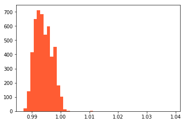

```python
plt.hist(x = 'density' , data = df , bins = 45,color='#ff5c33')
plt.show()
```

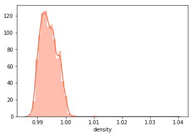

```python
sns.distplot(df['density'],color='#ff5c33')
```

### total sulfur dioxide-count plot

The distribution curve for total sulfur dioxide shows the following:

1. Curve is normally distibuted
2. There are outliers
3. Most of the wines have sulfur dioxide content as approximately 100

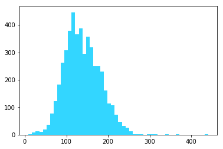

```python
plt.hist(x = 'total sulfur dioxide' , data = df , bins = 50,color='#33d6ff')
plt.show()
```

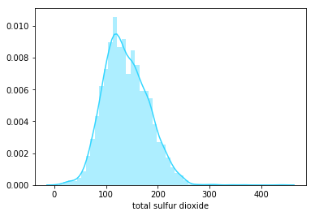

```python
sns.distplot(df['total sulfur dioxide'],color='#33d6ff')
```

### free sulfur dioxide-count plot

The graphs shows following attributes:

1. There are a lot many outliers beyong x=100 as can be seen from distplot
2. The curve has normal distribution
3. Most of the wine has free sulfur dioxide content ranging from 20%-50%

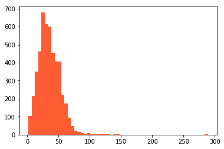

```python
plt.hist(x = 'free sulfur dioxide' , data = df , bins = 55,color='#ff5c33')
plt.show()
```

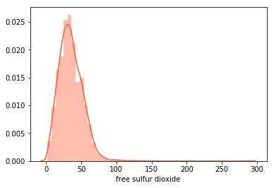

```python
sns.distplot(df['free sulfur dioxide'],color='#ff5c33')
```

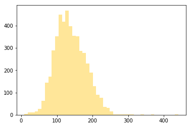

```python
plt.hist(x = 'total sulfur dioxide' , data = df , bins = 45,color='#ffe699')
plt.show()
```

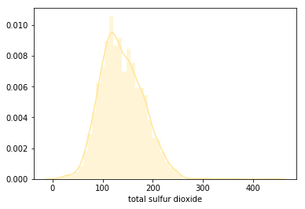

```python
sns.distplot(df['total sulfur dioxide'],color='#ffe699')
```

### residual sugar-count plot

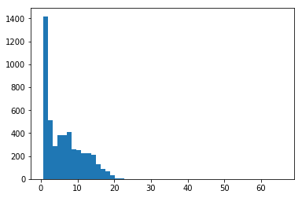

```python
plt.hist(x = 'residual sugar' , data = df , bins = 50)
plt.show()
```

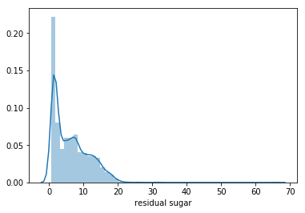

```python
sns.distplot(df['residual sugar'])
```

### citric acid-count plot

From the citric acid count plot we can say:

```
1. There is not any skeweness
2. There are a lot many outlierdbeyong x=0.75
```

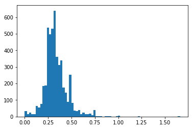

```python
plt.hist(x = 'citric acid' , data = df , bins = 70)
plt.show()
```

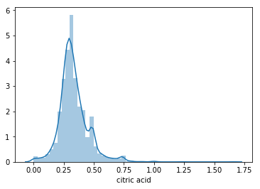

```python
sns.distplot(df['citric acid'])
```

### volatile acidity-count plot

The distribution curve for volatile acidity shows the following:

1. The distribution is normal
2. Most of the wine has volatile acidity=0.3
3. There are a lot many outliers

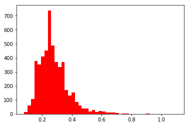

```python
plt.hist(x = 'volatile acidity' , data = df , bins = 45,color='red')
plt.show()
```

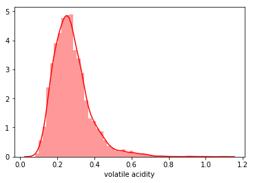

```python
sns.distplot(df['volatile acidity'],color='red')
```

### fixed acidity-count plot

The distribution curve for fixed acidity shows the following:

1. Most of the wine have fixed acidity equal to 6.5% to 7.5%
2. The distribution seems to be normal

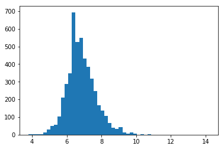

```python
plt.hist(x = 'fixed acidity' , data = df , bins = 50)
plt.show()
```

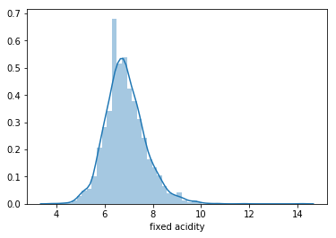

```python
sns.distplot(df['fixed acidity'])
```

## Bivariate Analysis

"Bi" means two while "variate" means variable.So Bivariate means two variables. Hence Bivariate Analysis works on two different variables showing how they are correlated. Bivariate analysis shows us the dependency of one attribute on another.

Let's see the correlation between two variables:

```python
df.corr()
```

|  | fixed acidity | volatile acidity | citric acid | residual sugar | chlorides | free sulfur dioxide | total sulfur dioxide | density | pH | sulphates | alcohol | quality |
| --- | --- | --- | --- | --- | --- | --- | --- | --- | --- | --- | --- | --- |
| fixed acidity | 1.000000 | -0.022697 | 0.289181 | 0.089021 | 0.023086 | -0.049396 | 0.091070 | 0.265331 | -0.425858 | -0.017143 | -0.120881 | -0.113663 |
| volatile acidity | -0.022697 | 1.000000 | -0.149472 | 0.064286 | 0.070512 | -0.097012 | 0.089261 | 0.027114 | -0.031915 | -0.035728 | 0.067718 | -0.194723 |
| citric acid | 0.289181 | -0.149472 | 1.000000 | 0.094212 | 0.114364 | 0.094077 | 0.121131 | 0.149503 | -0.163748 | 0.062331 | -0.075729 | -0.009209 |
| residual sugar | 0.089021 | 0.064286 | 0.094212 | 1.000000 | 0.088685 | 0.299098 | 0.401439 | 0.838966 | -0.194133 | -0.026664 | -0.450631 | -0.097577 |
| chlorides | 0.023086 | 0.070512 | 0.114364 | 0.088685 | 1.000000 | 0.101392 | 0.198910 | 0.257211 | -0.090439 | 0.016763 | -0.360189 | -0.209934 |
| free sulfur dioxide | -0.049396 | -0.097012 | 0.094077 | 0.299098 | 0.101392 | 1.000000 | 0.615501 | 0.294210 | -0.000618 | 0.059217 | -0.250104 | 0.008158 |
| total sulfur dioxide | 0.091070 | 0.089261 | 0.121131 | 0.401439 | 0.198910 | 0.615501 | 1.000000 | 0.529881 | 0.002321 | 0.134562 | -0.448892 | -0.174737 |
| density | 0.265331 | 0.027114 | 0.149503 | 0.838966 | 0.257211 | 0.294210 | 0.529881 | 1.000000 | -0.093591 | 0.074493 | -0.780138 | -0.307123 |
| pH | -0.425858 | -0.031915 | -0.163748 | -0.194133 | -0.090439 | -0.000618 | 0.002321 | -0.093591 | 1.000000 | 0.155951 | 0.121432 | 0.099427 |
| sulphates | -0.017143 | -0.035728 | 0.062331 | -0.026664 | 0.016763 | 0.059217 | 0.134562 | 0.074493 | 0.155951 | 1.000000 | -0.017433 | 0.053678 |
| alcohol | -0.120881 | 0.067718 | -0.075729 | -0.450631 | -0.360189 | -0.250104 | -0.448892 | -0.780138 | 0.121432 | -0.017433 | 1.000000 | 0.435575 |
| quality | -0.113663 | -0.194723 | -0.009209 | -0.097577 | -0.209934 | 0.008158 | -0.174737 | -0.307123 | 0.099427 | 0.053678 | 0.435575 | 1.000000 |

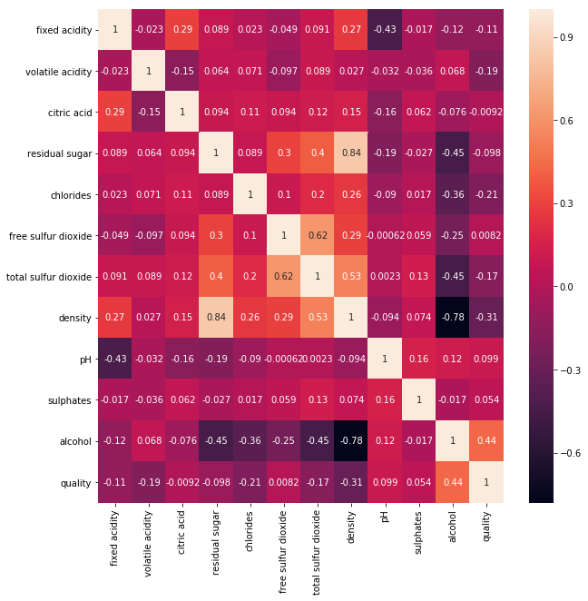

```python
# annot=True shows the relation magnitude(the numbers on each block) between two attributes
# plt.figure(figsize=(1,10)) resizes the figure and it should be written before creating the plot.
plt.figure(figsize=(10,10))
sns.heatmap(df.corr(), annot=True)
plt.show()
```

### alcohol-quality plot

The alcohol-quality plot below helps us to draw the following conclusions:

1. There is positive correlation between alcohol content and quality of wine
2. Quality rating of 6 and 7 have highest alcohol content in the wine

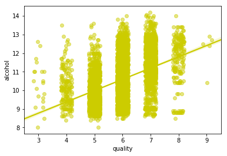

```python
sns.regplot(x = 'quality',y = 'alcohol',data = df , x_jitter=0.2, scatter_kws={'alpha':0.5},color='#cccc00')
```

### alcohol-density plot

We can draw following inferences from the alcohol-density plot drawn below

1. Alcohol content and density of wine have inverse relation(Negative correlation)
2. Wine having 14 % alcohol content have least density
3. Wine having 8.7% to 9% alcohol content have highest density

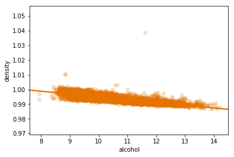

```python
sns.regplot(x = 'alcohol',y = 'density',data = df , x_jitter=0.1, scatter_kws={'alpha':0.2},color='#e67300')
```

### quality-density plot

Follwing inferences can be drawn from quality-density graph

1. There is negative correlation between quality and density of wine
2. Quality rating of 5 and 6 have highest density(1.00 to 1.005)
3. Quality rating of 9 have least density

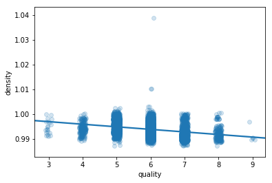

```python
sns.regplot(x = 'quality',y = 'density',data = df , x_jitter=0.1, scatter_kws={'alpha':0.2})
```

### quality-pH plot

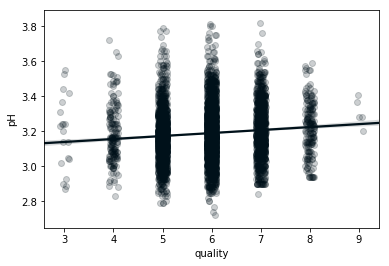

```python
sns.regplot(x = 'quality',y = 'pH',data = df , x_jitter=0.1, scatter_kws={'alpha':0.2},color='#00111a')
```

### alcohol-chlorides plot

From the alcohol-chlorides plot we can say

1. There are negatively correlated
2. Wine having alcohol content 14% have least chlorides percentage
3. Wine having alcohol content 9%-9.8% have highest chlorides percentage

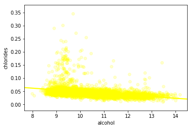

```python
sns.regplot(x = 'alcohol',y = 'chlorides',data = df , x_jitter=0.1, scatter_kws={'alpha':0.2},color='yellow')
```

### quality-chlorides plot

We can perceive the following facts from the quality-chlorides plot

1. Chlorides and Quality are negatively correlated
2. Quality rating of 5 and 6 have highets chlorides percentage.
3. Quality rating of 9 have least chlorides percentage

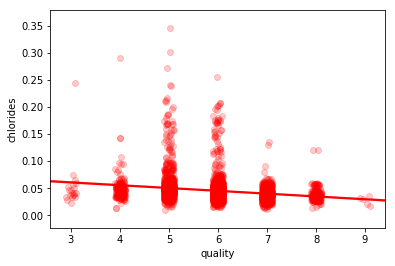

```python
sns.regplot(x = 'quality',y = 'chlorides',data = df , x_jitter=0.1, scatter_kws={'alpha':0.2},color='red')
```

## Mutivariate Analysis

"Multi" means many, "variate" means variable. Therefor Multi Variate analysis means analysison the basis of many variable. Here multiple different attributes are taken into account while reaching to a conclusion. It gives better result as compared to Single variate or Bi variate analysis because there are multiple factors taken together to reach to an inference in Multi variate analysis

### Quality-Alcohol-Density plot

We can draw follwing inferences

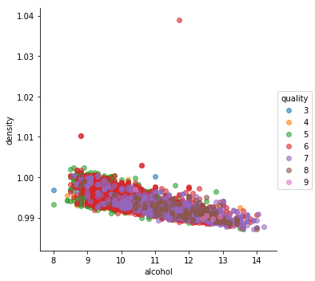

```python
sns.lmplot(x='alcohol',y='density',hue='quality',data=df,fit_reg=False,scatter_kws={'alpha':0.6})
```

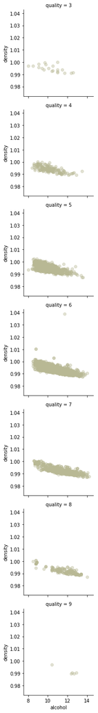

```python
grid=sns.FacetGrid(df,row='quality')
grid.map(plt.scatter,'alcohol','density',alpha=0.4,color='#b8b894')
```

### quality-alcohol-chlorides plot

From the distribution below, following conclusions cans be drawn

1. There is negative distribution of chloride% and alcohol %
2. As quality increases chlorides % decreases
3. Alcholo content is maximum for Quality rating 7

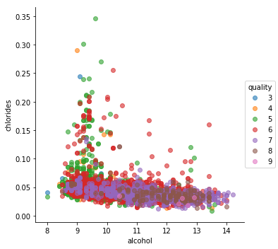

```python
sns.lmplot(x='alcohol',y='chlorides',hue='quality',data=df,fit_reg=False,scatter_kws={'alpha':0.6})
```

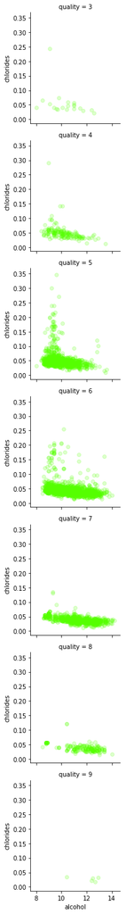

```python
grid=sns.FacetGrid(df,row='quality')
grid.map(plt.scatter,'alcohol','chlorides',alpha=0.2,color='#55ff00')
```

### quality-pH-density plot

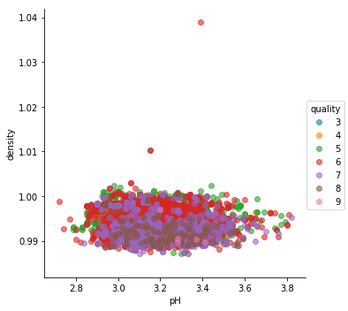

```python
sns.lmplot(x='pH',y='density',hue='quality',data=df,fit_reg=False,scatter_kws={'alpha':0.6})
```

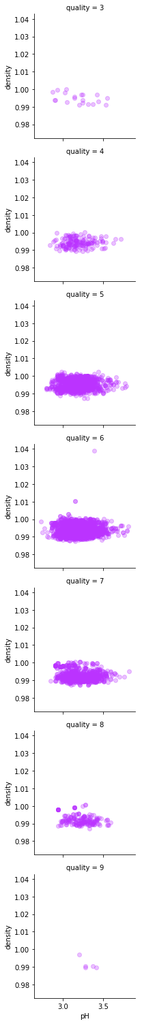

```python
grid=sns.FacetGrid(df,row='quality')
grid.map(plt.scatter,'pH','density',alpha=0.3,color="#bb33ff")
```

## Plot 2

## quality-alcohol-density plot

This graph is capable of relating the quality of wine with its alcohol concentration as well as density of wine. This plot best describes the density and alcohol concentration mixture to make a high quality wine which is the most important aspect of any wine producer

## Plot 3

### Quality - pH plot

This plot is self sufficient to get a deeper insight as to how much should be the pH of a quality wine. pH decides the taste(sweet/sour) at the end when the wine is ready for distribution Hence this plot has been decided to be in the list of 3 most important plots